CS F364: Design & Analysis of Algorithms

# Asymptotic Notation & Merge Sort

Lecture 3 |2026-05-21

Dr. Tulasimohan Molli BITS Pilani, Hyderabad Campus

# Asymptotic Notations...

- Asymptotic Notations...
- Analysis of merge sort
- Proof of correctness

## Small Oh (Little-$o$)

$o$-notation For a given Function $g(n)$, we denote by $o(g(n))$ the set of functions $o(g(n)) = \{f(n)|\mbox{for any positive constant } c, \mbox{ there exists a constant } n_0 \mbox{ such that } 0\leq f(n) < cg(n) \mbox{ for all } n\geq n_0\}$.

- This indicates a loose bound: $f(n) = o(g(n))$ means $f(n)$ grows strictly slower than $g(n)$.
- **Example:** $2n=o(n^2)$ but $2n^2\neq o(n^2)$.

## Small Omega (Little-$\omega$)

$\omega$-notation For a given function $g(n)$, we denote by $\omega(g(n))$ the set of functions $\omega(g(n)) = \{f(n)| \mbox{ for any positive constant } c, \mbox{ there exists a constant } n_0 \mbox{ such that } 0\leq cg(n) < f(n) \mbox{ for all } n\geq n_0\}$.

- This indicates a loose bound: $f(n)=\omega(g(n))$ means $f(n)$ grows strictly faster than $g(n)$.
- **Example:** $\frac{n^2}{2} = \omega(n)$ but $\frac{n^2}{2}\neq\omega(n^2)$.

## Time Complexity of an Algorithm

- **Worst-Case Complexity:** The worst case complexity of an algorithm is the function defined by the maximum number of steps taken on any instance of size $n$.
- **Best-Case Complexity:** The best case complexity of an algorithm is the function defined by the minimum number of steps taken on any instance of size $n$.
- **Average-Case Complexity:** The average case complexity of an algorithm is the function defined by an average number of steps taken on any instance of size $n$.

## Recurrence for Divide and Conquer

A recurrence for the running time of a divide-and-conquer algorithm falls out from the three steps of the basic paradigm. Suppose $\mathbf{T(n)}$ be the running time on a problem of size $n$.

- Suppose that our division of the problem yields $\mathbf{a}$ subproblems, each of which is $\mathbf{1/b}$ the size of the original.
  - It takes time $\mathbf{T(n/b)}$ to solve one subproblem of size $\mathbf{n/b}$, and so it takes time $\mathbf{aT(n/b)}$ to solve $\mathbf{a}$ of them.
- If we take $\mathbf{D(n)}$ time to divide the problem into subproblems, and $\mathbf{C(n)}$ time to combine the solutions to the subproblems into the solution to the original problem, we get the recurrence:
  $$T(n) = \begin{cases}
  \Theta(1) & \mbox{ if } n\leq c \\
  aT(n/b) + D(n) + C(n) & \mbox{ otherwise }
  \end{cases}$$

# Analysis of merge sort

- Asymptotic Notations...
- Analysis of merge sort
- Proof of correctness

## Analysis of merge sort

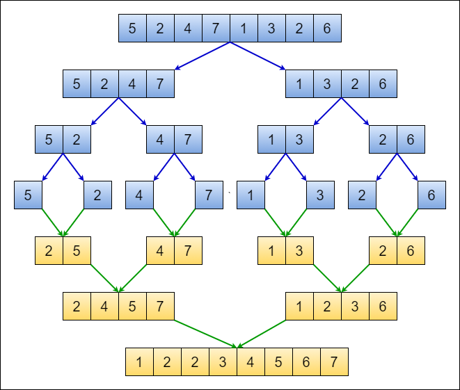

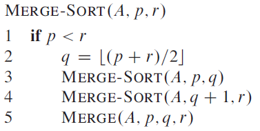

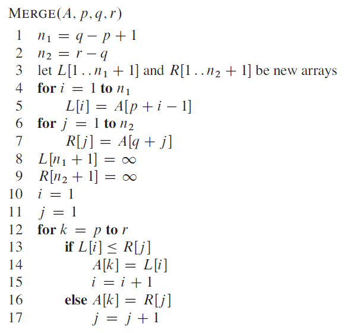

## Analysis of merge sort

We reason as follows to set up the recurrence for $T(n)$:

- **Divide:** The divide step just computes the middle of the subarray, which takes constant time. Thus, $D(n)=\Theta(1)$.
- **Conquer:** We recursively solve two subproblems, each of size $n/2$, which contributes $2T(n/2)$ to the running time.
- **Combine:** MERGE procedure on an $n$-element subarray takes time $\Theta(n)$, and so $C(n)=\Theta(n)$.

Thus, we get the following recurrence relation of merge sort:
$$T(n) = \begin{cases}
\Theta(1) & \mbox{ if } n=1, \\
2T(n/2) + \Theta(n) & \mbox{ if } n>1,
\end{cases}$$

## Analysis of merge sort

We can rewrite the recurrence as follows:
$$T(n) = \begin{cases}
c & \mbox{ if } n=1, \\
2T(n/2) + cn & \mbox{ if } n>1,
\end{cases}$$
where the constant $c$ represents the time required to solve problems of size $1$ as well as the time per array element of the divide and combine step.

We can solve this recurrence using a recursion tree.

## Analysis of merge sort

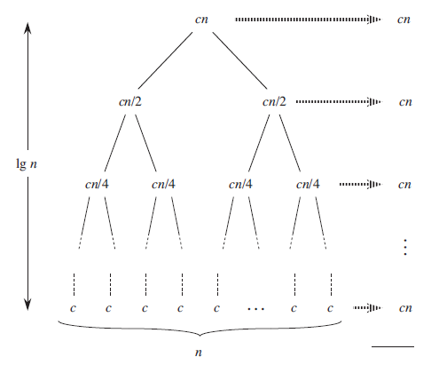

- The total number of levels of the recursion tree is $\log_2{n}+1$, where $n$ is the number of leaves, corresponding to the input size.

## Analysis of merge sort

The number of levels of the recursion tree is $\log_2{n}+1$ where $n$ is the number of leaves.

We can prove this by using induction on the number of leaf nodes.  
**Base Case:** When $n=1$, the number of levels is $\log_2{1}+1 = 1$ which is true.  
**Inductive Hypothesis:** Assume that the number of levels of a recursion tree with $2^n$ leaves is $\log_2(2^n)+1 = n+1$.  
**Inductive Step:** Because we are assuming that the input size is a power of $2$, the next input size to consider is $2^{n+1}$. A tree with $l=2^{n+1}$ leaves has one more level than a tree with $2^n$ leaves, and so the total number of levels is $(n+1)+1 = \log_2{2^{n+1}}+1$.

**Following the above result, $T(n) = cn\log_2{n}+cn$. Ignoring the low order term and the constant $c$ gives us $T(n) = \Theta(n\log{n})$.**

# Proof of correctness

- Asymptotic Notations...
- Analysis of merge sort
- Proof of correctness

## Insertion Sort

## Correctness of Insertion Sort

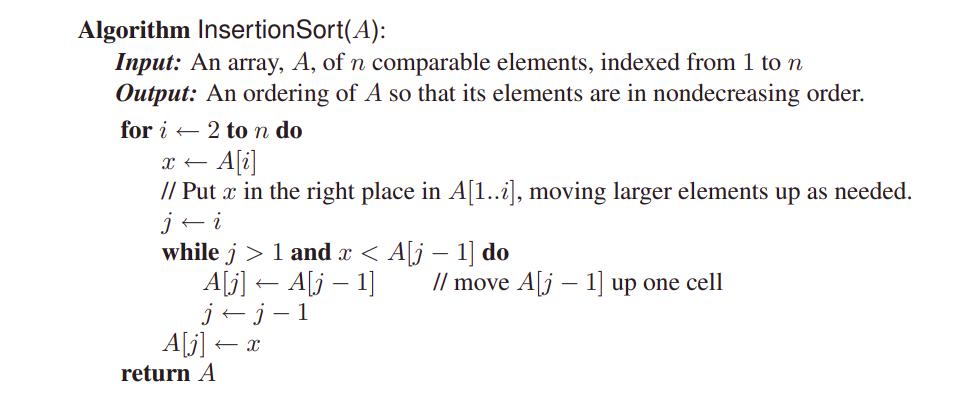

## Merge Sort

## Correctness of Merge Sort

- **Loop Invariant:** (in class)
- **Initialization:** (in class)
- **Maintenance:** (in class)
- **Termination:** (in class)